# Rentabilidad de grandes eventos deportivos en el contexto de los países BRICS

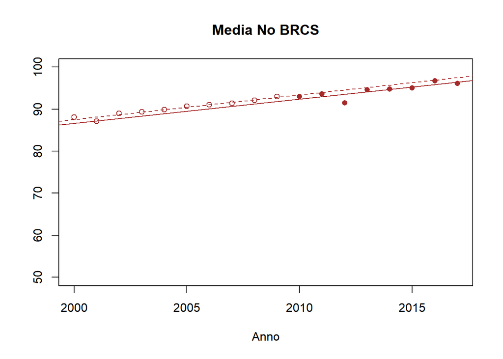

**Coeficientes de Correlacion - Acceso a la electricidad BRCS (% de población)**

| China |  |  |
| --- | --- | --- |
| Tendencia | 2000 - 2008 | POS |
| Correlación con Promedio mundial | 2000 - 2008 | 0.999 |
| Correlación con Promedio no BRCS | 2000 - 2008 | 0.947 |
| Tendencia | 2008 - 2017 | POS |
| Correlación con Promedio mundial | 2008 - 2017 | 0.845 |
| Correlación con Promedio no BRCS | 2008 - 2017 | 0.75 |
| Sudafrica |  |  |
| Tendencia | 2000 - 2010 | POS |
| Correlación con Promedio mundial | 2000 - 2010 | 0.883 |
| Correlación con Promedio no BRCS | 2000 - 2010 | 0.908 |
| Tendencia | 2010 - 2017 | POS |
| Correlación con Promedio mundial | 2010 - 2017 | 0.588 |
| Correlación con Promedio no BRCS | 2010 - 2017 | 0.339 |
| Brasil |  |  |
| Tendencia | 2000 - 2014 | POS |
| Correlación con Promedio mundial | 2000 - 2014 | 0.965 |
| Correlación con Promedio no BRCS | 2000 - 2014 | 0.907 |
| Tendencia | 2014 - 2017 | POS |
| Correlación con Promedio mundial | 2014 - 2017 | 0.934 |
| Correlación con Promedio no BRCS | 2014 - 2017 | 0.992 |
| Rusia |  |  |
| Tendencia | 2000 - 2014 | — |
| Correlación con Promedio mundial | 2000 - 2014 | NA |
| Correlación con Promedio no BRCS | 2000 - 2014 | NA |
| Tendencia | 2014 - 2017 | — |
| Correlación con Promedio mundial | 2014 - 2017 | NA |
| Correlación con Promedio no BRCS | 2014 - 2017 | NA |

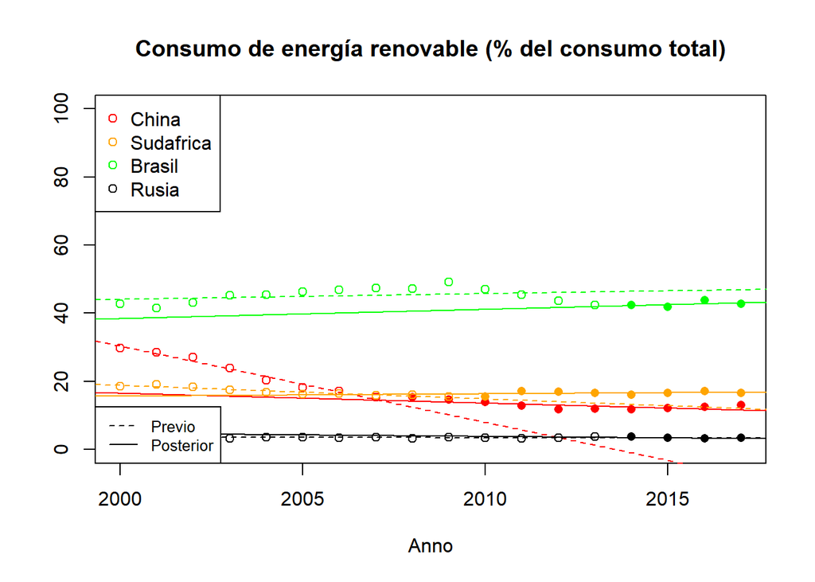

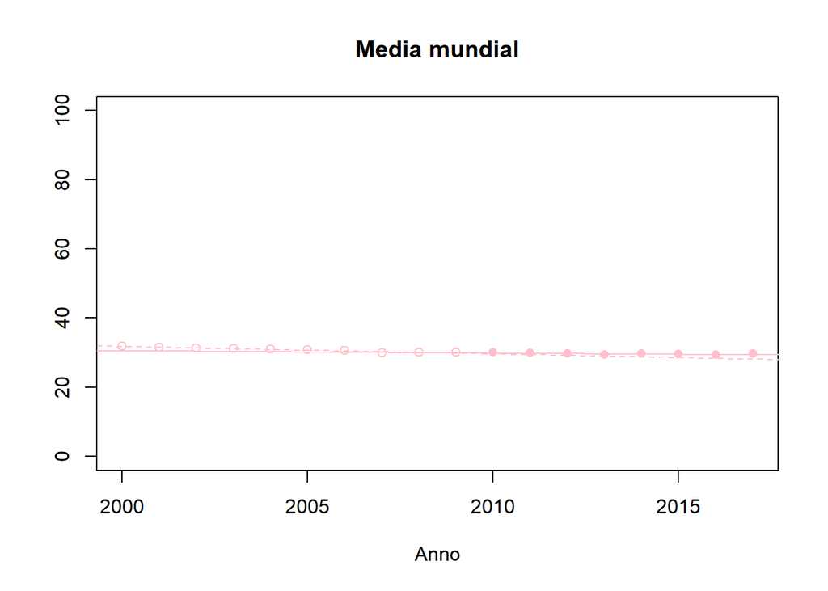

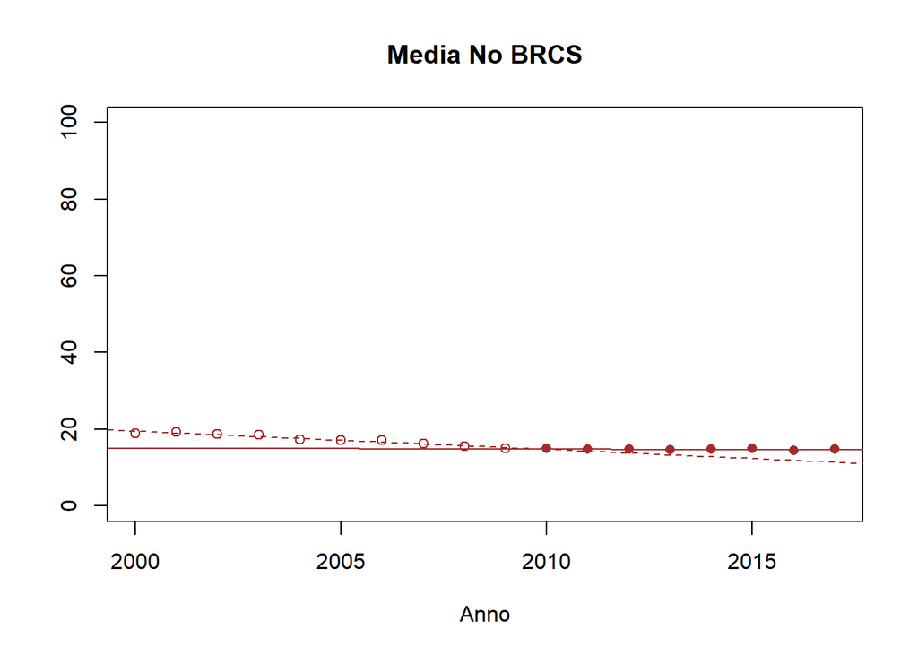

**Coeficientes de Correlacion - Consumo de energía renovable (% del consumo total)**

| China |  |  |
| --- | --- | --- |
| Tendencia | 2000 - 2008 | NEG |
| Correlación con Promedio mundial | 2000 - 2008 | 0.952 |
| Correlación con Promedio no BRCS | 2000 - 2008 | 0.967 |
| Tendencia | 2008 - 2017 | NEG |
| Correlación con Promedio mundial | 2008 - 2017 | 0.729 |
| Correlación con Promedio no BRCS | 2008 - 2017 | 0.907 |
| Sudafrica |  |  |
| Tendencia | 2000 - 2010 | NEG |
| Correlación con Promedio mundial | 2000 - 2010 | 0.917 |
| Correlación con Promedio no BRCS | 2000 - 2010 | 0.93 |
| Tendencia | 2010 - 2017 | POS |
| Correlación con Promedio mundial | 2010 - 2017 | 0.038 |
| Correlación con Promedio no BRCS | 2010 - 2017 | -0.44 |
| Brasil |  |  |
| Tendencia | 2000 - 2014 | POS |
| Correlación con Promedio mundial | 2000 - 2014 | -0.423 |
| Correlación con Promedio no BRCS | 2000 - 2014 | -0.46 |
| Tendencia | 2014 - 2017 | POS |
| Correlación con Promedio mundial | 2014 - 2017 | -0.187 |
| Correlación con Promedio no BRCS | 2014 - 2017 | 0.511 |
| Rusia |  |  |
| Tendencia | 2000 - 2014 | NEG |
| Correlación con Promedio mundial | 2000 - 2014 | 0.153 |
| Correlación con Promedio no BRCS | 2000 - 2014 | 0.132 |
| Tendencia | 2014 - 2017 | NEG |
| Correlación con Promedio mundial | 2014 - 2017 | -0.606 |
| Correlación con Promedio no BRCS | 2014 - 2017 | -0.539 |

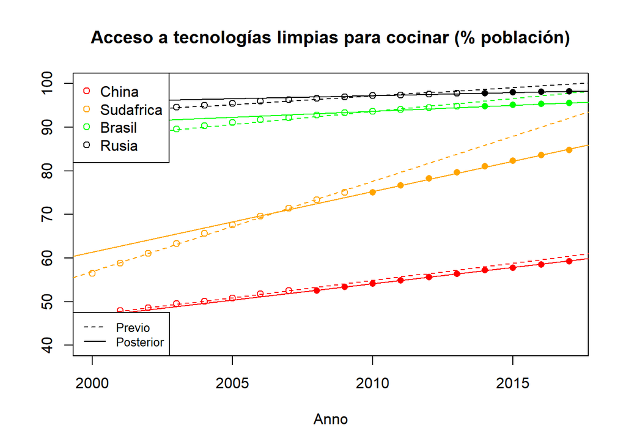

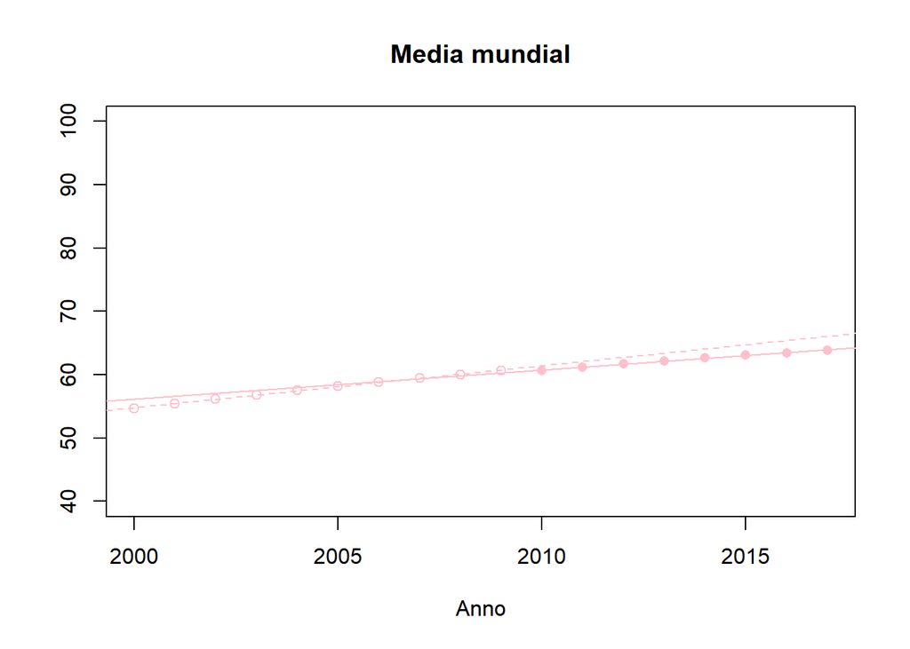

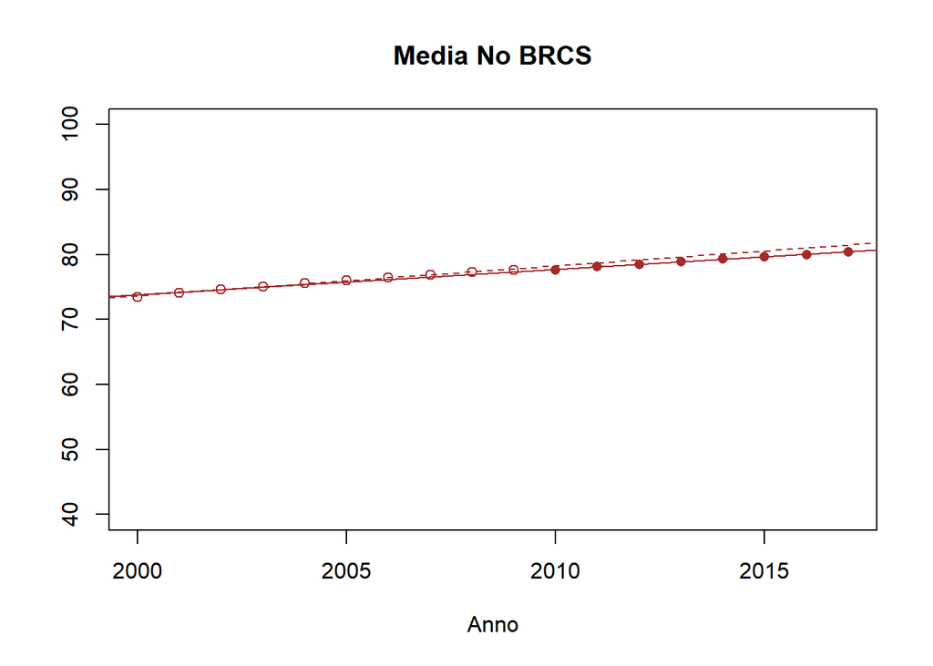

**Coeficientes de Correlacion - Acceso a tecnologías limpias para cocinar (% población)**

| China |  |  |
| --- | --- | --- |
| Tendencia | 2000 - 2008 | POS |
| Correlación con Promedio mundial | 2000 - 2008 | 0.998 |
| Correlación con Promedio no BRCS | 2000 - 2008 | 0.998 |
| Tendencia | 2008 - 2017 | POS |
| Correlación con Promedio mundial | 2008 - 2017 | 0.999 |
| Correlación con Promedio no BRCS | 2008 - 2017 | 0.999 |
| Sudafrica |  |  |
| Tendencia | 2000 - 2010 | POS |
| Correlación con Promedio mundial | 2000 - 2010 | 1 |
| Correlación con Promedio no BRCS | 2000 - 2010 | 1 |
| Tendencia | 2010 - 2017 | POS |
| Correlación con Promedio mundial | 2010 - 2017 | 1 |
| Correlación con Promedio no BRCS | 2010 - 2017 | 0.998 |
| Brasil |  |  |
| Tendencia | 2000 - 2014 | POS |
| Correlación con Promedio mundial | 2000 - 2014 | 0.996 |
| Correlación con Promedio no BRCS | 2000 - 2014 | 0.994 |
| Tendencia | 2014 - 2017 | POS |
| Correlación con Promedio mundial | 2014 - 2017 | 1 |
| Correlación con Promedio no BRCS | 2014 - 2017 | 0.998 |
| Rusia |  |  |
| Tendencia | 2000 - 2014 | POS |
| Correlación con Promedio mundial | 2000 - 2014 | 0.992 |
| Correlación con Promedio no BRCS | 2000 - 2014 | 0.989 |
| Tendencia | 2014 - 2017 | POS |
| Correlación con Promedio mundial | 2014 - 2017 | 0.992 |
| Correlación con Promedio no BRCS | 2014 - 2017 | 0.99 |

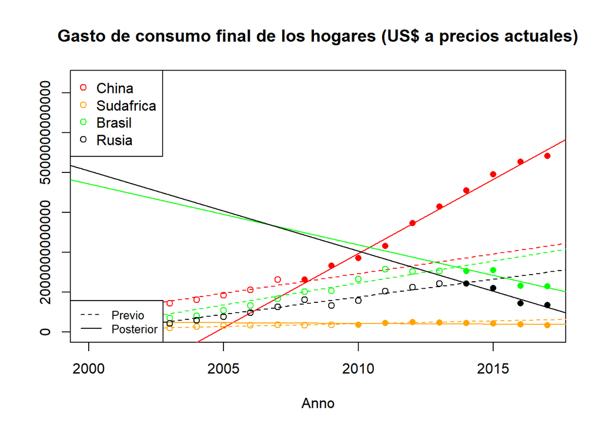

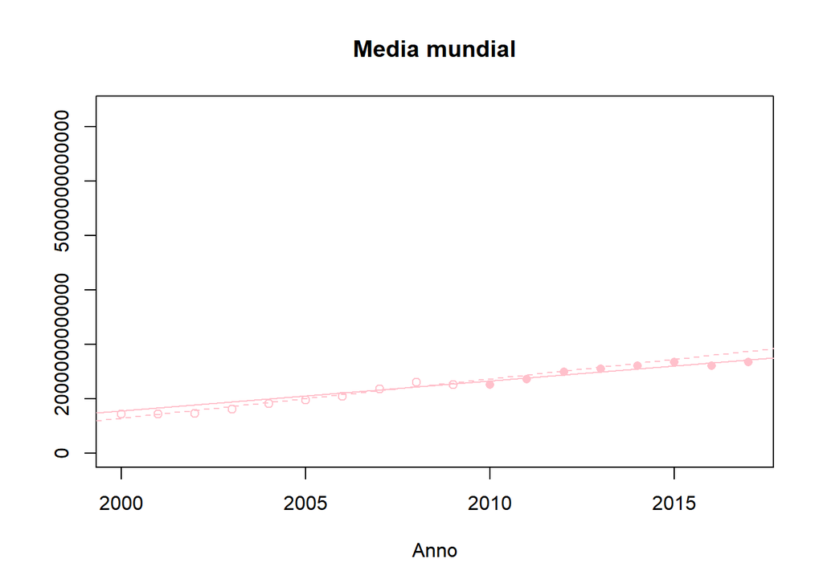

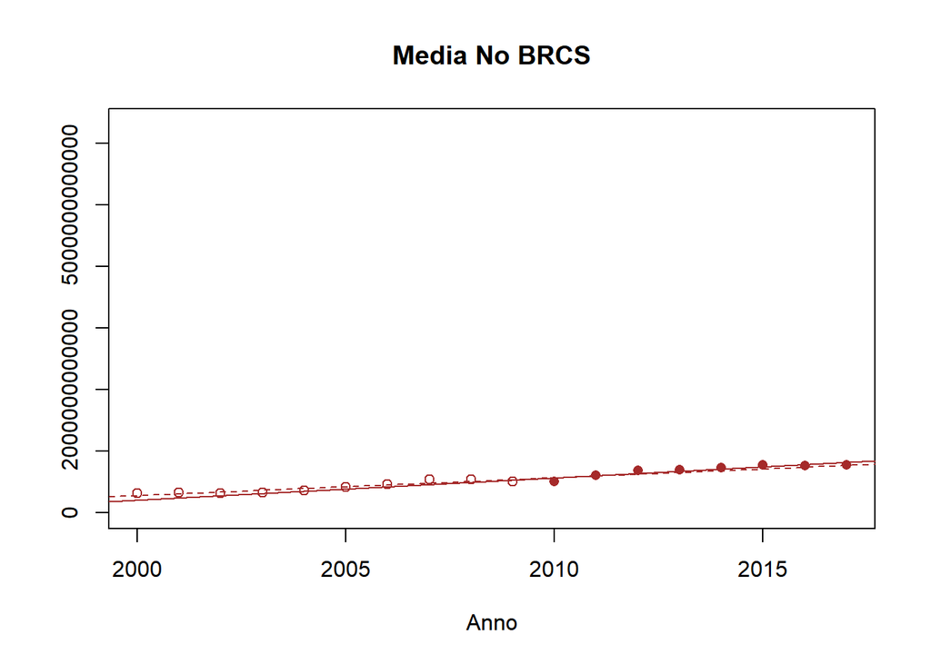

**Coeficientes de Correlacion - Gasto de consumo final de los hogares (US$ a precios actuales)**

| China |  |  |
| --- | --- | --- |
| Tendencia | 2000 - 2008 | POS |
| Correlación con Promedio mundial | 2000 - 2008 | 0.984 |
| Correlación con Promedio no BRCS | 2000 - 2008 | 0.985 |
| Tendencia | 2008 - 2017 | POS |
| Correlación con Promedio mundial | 2008 - 2017 | 0.972 |
| Correlación con Promedio no BRCS | 2008 - 2017 | 0.978 |
| Sudafrica |  |  |
| Tendencia | 2000 - 2010 | POS |
| Correlación con Promedio mundial | 2000 - 2010 | 0.925 |
| Correlación con Promedio no BRCS | 2000 - 2010 | 0.915 |
| Tendencia | 2010 - 2017 | NEG |
| Correlación con Promedio mundial | 2010 - 2017 | -0.267 |
| Correlación con Promedio no BRCS | 2010 - 2017 | -0.238 |
| Brasil |  |  |
| Tendencia | 2000 - 2014 | POS |
| Correlación con Promedio mundial | 2000 - 2014 | 0.975 |
| Correlación con Promedio no BRCS | 2000 - 2014 | 0.981 |
| Tendencia | 2014 - 2017 | NEG |
| Correlación con Promedio mundial | 2014 - 2017 | -0.665 |
| Correlación con Promedio no BRCS | 2014 - 2017 | -0.876 |
| Rusia |  |  |
| Tendencia | 2000 - 2014 | POS |
| Correlación con Promedio mundial | 2000 - 2014 | 0.993 |
| Correlación con Promedio no BRCS | 2000 - 2014 | 0.991 |
| Tendencia | 2014 - 2017 | NEG |
| Correlación con Promedio mundial | 2014 - 2017 | -0.723 |
| Correlación con Promedio no BRCS | 2014 - 2017 | -0.949 |

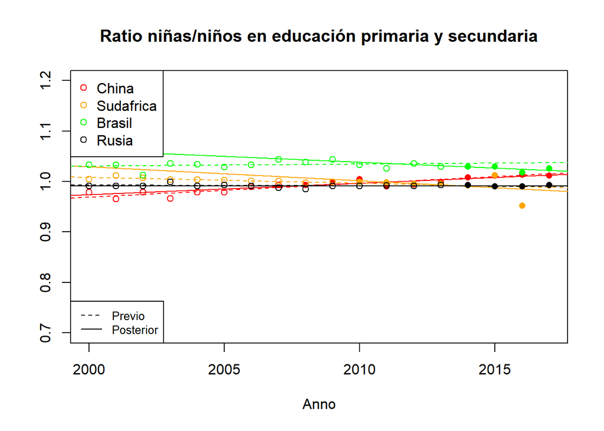

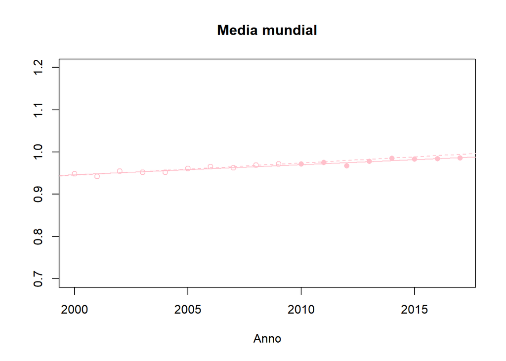

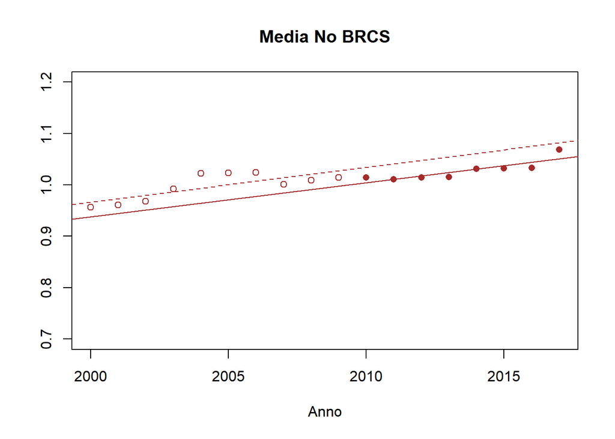

**Coeficientes de Correlacion - Ratio niñas/niños en educación primaria y secundaria**

| China |  |  |
| --- | --- | --- |
| Tendencia | 2000 - 2008 | POS |
| Correlación con Promedio mundial | 2000 - 2008 | 0.818 |
| Correlación con Promedio no BRCS | 2000 - 2008 | 0.457 |
| Tendencia | 2008 - 2017 | POS |
| Correlación con Promedio mundial | 2008 - 2017 | 0.762 |
| Correlación con Promedio no BRCS | 2008 - 2017 | 0.597 |
| Sudafrica |  |  |
| Tendencia | 2000 - 2010 | NEG |
| Correlación con Promedio mundial | 2000 - 2010 | -0.89 |
| Correlación con Promedio no BRCS | 2000 - 2010 | -0.712 |
| Tendencia | 2010 - 2017 | NEG |
| Correlación con Promedio mundial | 2010 - 2017 | -0.234 |
| Correlación con Promedio no BRCS | 2010 - 2017 | -0.32 |
| Brasil |  |  |
| Tendencia | 2000 - 2014 | POS |
| Correlación con Promedio mundial | 2000 - 2014 | 0.165 |
| Correlación con Promedio no BRCS | 2000 - 2014 | 0.249 |
| Tendencia | 2014 - 2017 | NEG |
| Correlación con Promedio mundial | 2014 - 2017 | -0.237 |
| Correlación con Promedio no BRCS | 2014 - 2017 | -0.495 |
| Rusia |  |  |
| Tendencia | 2000 - 2014 | NEG |
| Correlación con Promedio mundial | 2000 - 2014 | -0.208 |
| Correlación con Promedio no BRCS | 2000 - 2014 | -0.059 |
| Tendencia | 2014 - 2017 | POS |
| Correlación con Promedio mundial | 2014 - 2017 | -0.513 |
| Correlación con Promedio no BRCS | 2014 - 2017 | -0.49 |

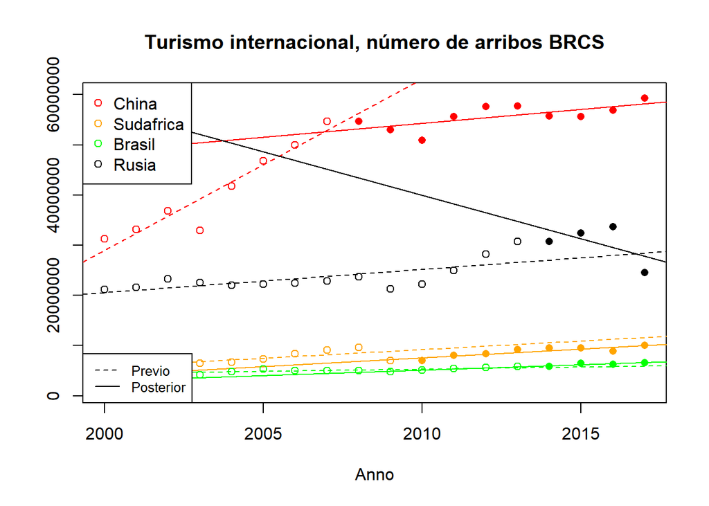

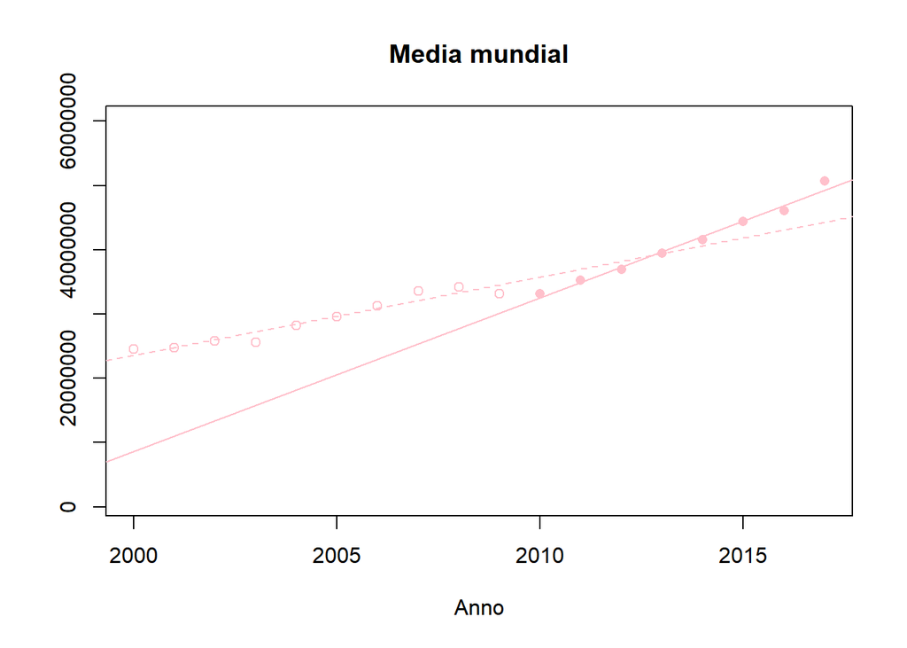

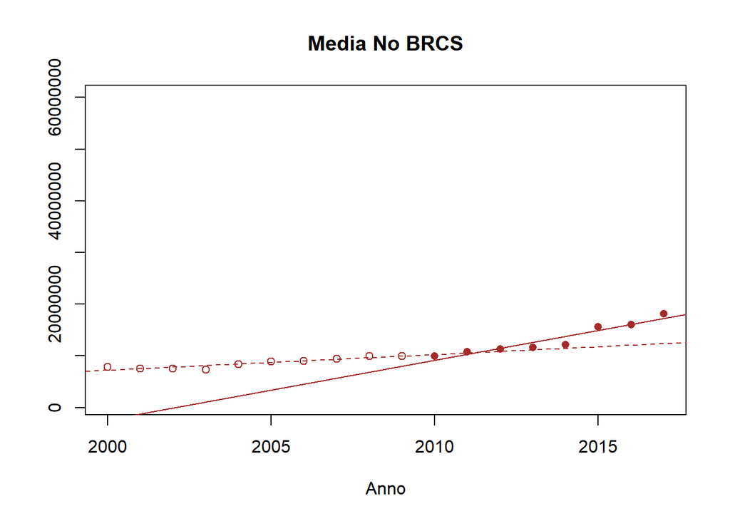

**Coeficientes de Correlacion - Turismo internacional, número de arribos BRCS**

| China |  |  |
| --- | --- | --- |
| Tendencia | 2000 - 2008 | POS |
| Correlación con Promedio mundial | 2000 - 2008 | 0.991 |
| Correlación con Promedio no BRCS | 2000 - 2008 | 0.95 |
| Tendencia | 2008 - 2017 | POS |
| Correlación con Promedio mundial | 2008 - 2017 | 0.595 |
| Correlación con Promedio no BRCS | 2008 - 2017 | 0.651 |
| Sudafrica |  |  |
| Tendencia | 2000 - 2010 | POS |
| Correlación con Promedio mundial | 2000 - 2010 | 0.881 |
| Correlación con Promedio no BRCS | 2000 - 2010 | 0.789 |
| Tendencia | 2010 - 2017 | POS |
| Correlación con Promedio mundial | 2010 - 2017 | 0.77 |
| Correlación con Promedio no BRCS | 2010 - 2017 | 0.652 |
| Brasil |  |  |
| Tendencia | 2000 - 2014 | POS |
| Correlación con Promedio mundial | 2000 - 2014 | 0.702 |
| Correlación con Promedio no BRCS | 2000 - 2014 | 0.763 |
| Tendencia | 2014 - 2017 | POS |
| Correlación con Promedio mundial | 2014 - 2017 | 0.815 |
| Correlación con Promedio no BRCS | 2014 - 2017 | 0.642 |
| Rusia |  |  |
| Tendencia | 2000 - 2014 | POS |
| Correlación con Promedio mundial | 2000 - 2014 | 0.77 |
| Correlación con Promedio no BRCS | 2000 - 2014 | 0.737 |
| Tendencia | 2014 - 2017 | NEG |
| Correlación con Promedio mundial | 2014 - 2017 | -0.496 |
| Correlación con Promedio no BRCS | 2014 - 2017 | -0.406 |

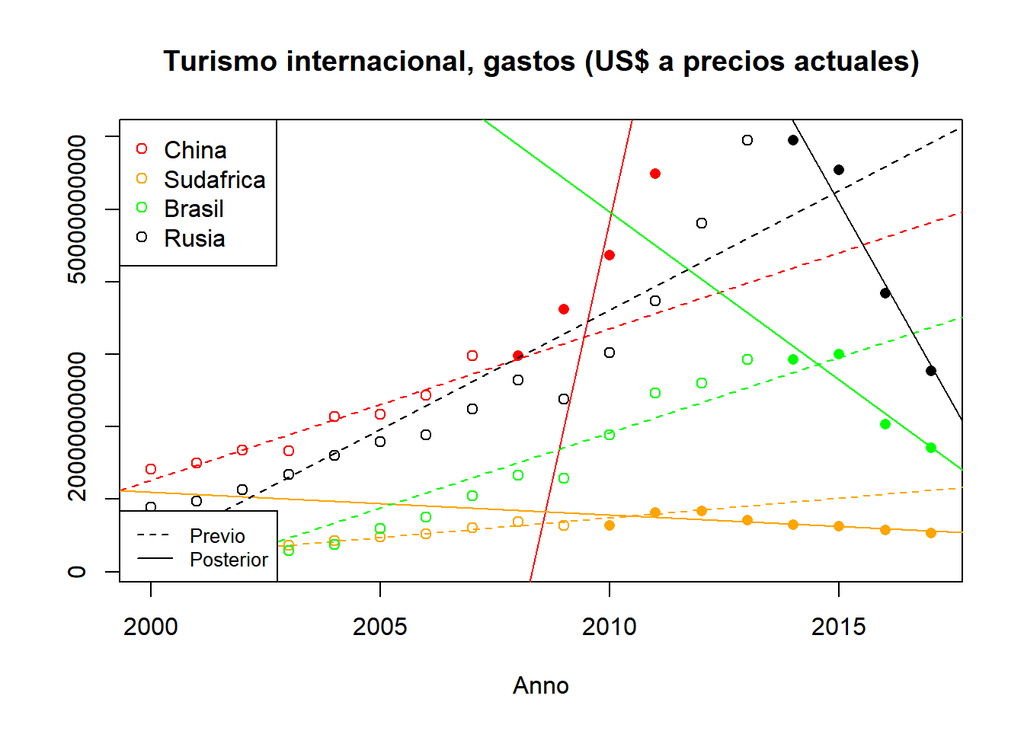

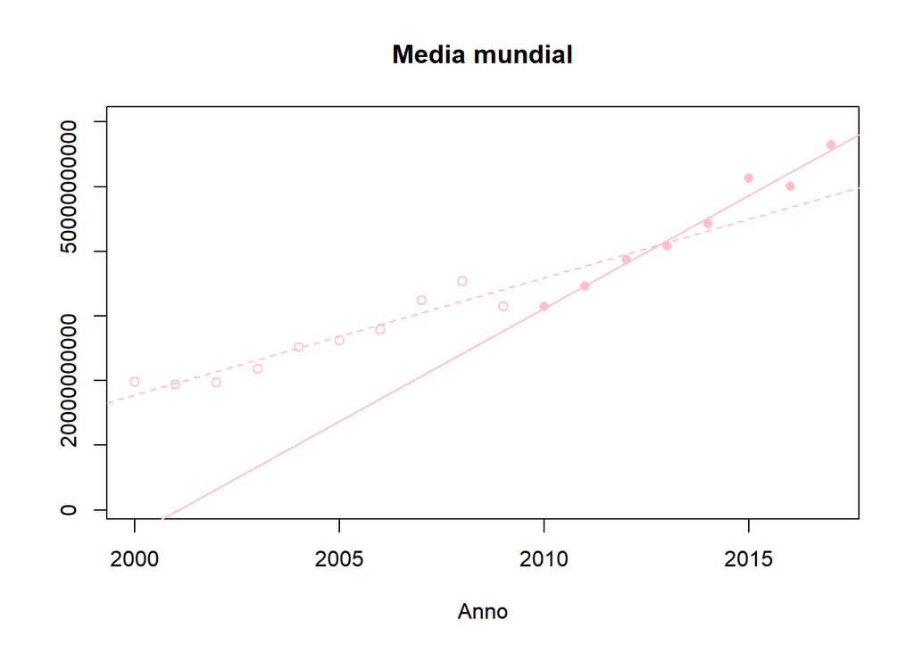

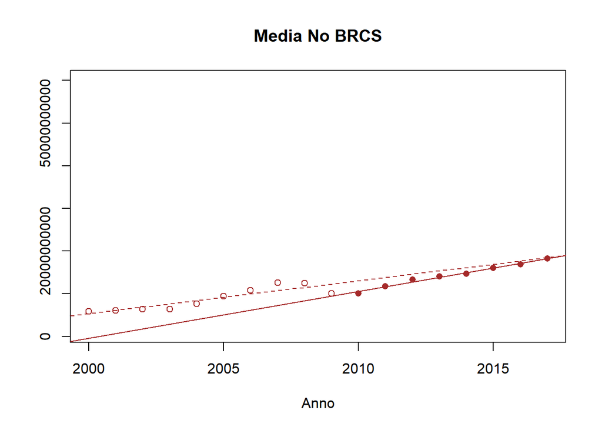

**Coeficientes de Correlacion - Turismo internacional, gastos (US$ a precios actuales)**

| China |  |  |
| --- | --- | --- |
| Tendencia | 2000 - 2008 | POS |
| Correlación con Promedio mundial | 2000 - 2008 | 0.987 |
| Correlación con Promedio no BRCS | 2000 - 2008 | 0.974 |
| Tendencia | 2008 - 2017 | POS |
| Correlación con Promedio mundial | 2008 - 2017 | 0.961 |
| Correlación con Promedio no BRCS | 2008 - 2017 | 0.911 |
| Sudafrica |  |  |
| Tendencia | 2000 - 2010 | POS |
| Correlación con Promedio mundial | 2000 - 2010 | 0.986 |
| Correlación con Promedio no BRCS | 2000 - 2010 | 0.932 |
| Tendencia | 2010 - 2017 | NEG |
| Correlación con Promedio mundial | 2010 - 2017 | -0.865 |
| Correlación con Promedio no BRCS | 2010 - 2017 | -0.906 |
| Brasil |  |  |
| Tendencia | 2000 - 2014 | POS |
| Correlación con Promedio mundial | 2000 - 2014 | 0.951 |
| Correlación con Promedio no BRCS | 2000 - 2014 | 0.889 |
| Tendencia | 2014 - 2017 | NEG |
| Correlación con Promedio mundial | 2014 - 2017 | -0.897 |
| Correlación con Promedio no BRCS | 2014 - 2017 | -0.966 |
| Rusia |  |  |
| Tendencia | 2000 - 2014 | POS |
| Correlación con Promedio mundial | 2000 - 2014 | 0.948 |
| Correlación con Promedio no BRCS | 2000 - 2014 | 0.883 |
| Tendencia | 2014 - 2017 | NEG |
| Correlación con Promedio mundial | 2014 - 2017 | -0.905 |
| Correlación con Promedio no BRCS | 2014 - 2017 | -0.996 |

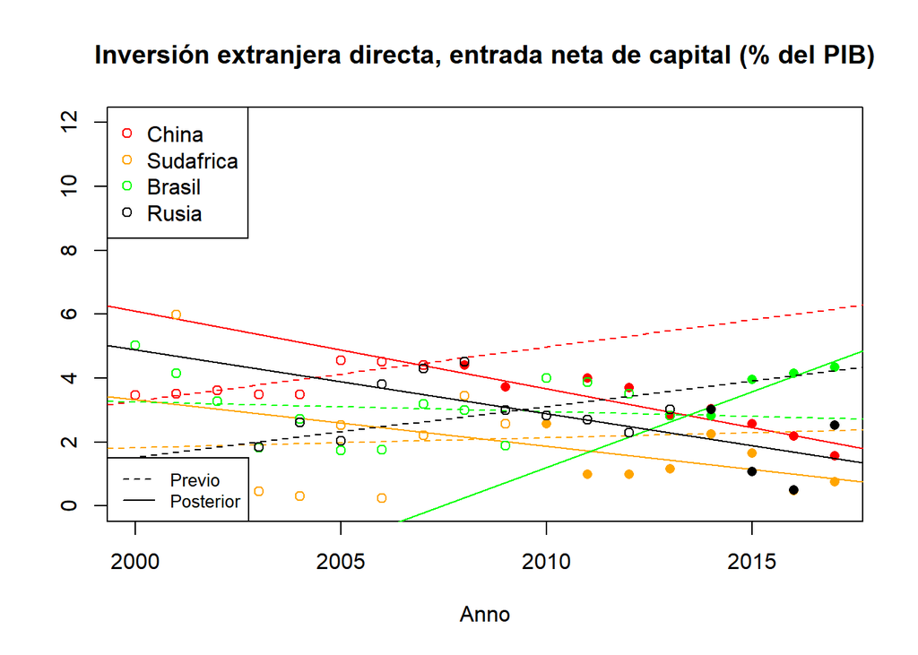

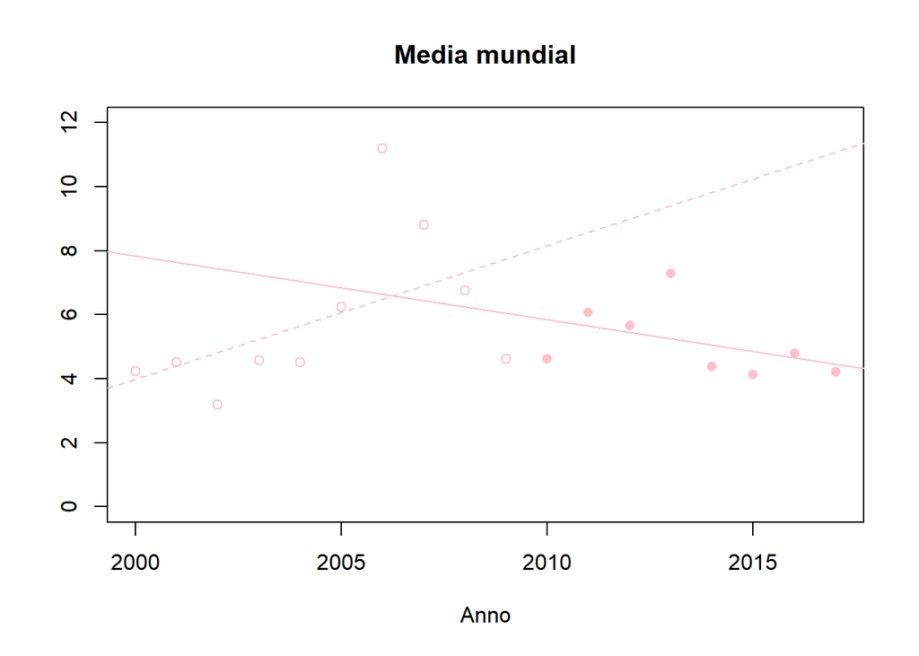

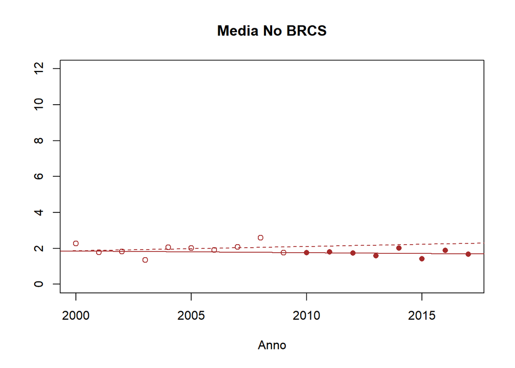

**Coeficientes de Correlacion - Inversión extranjera directa, entrada neta de capital (% del PIB)**

| China |  |  |
| --- | --- | --- |
| Tendencia | 2000 - 2008 | POS |
| Correlación con Promedio mundial | 2000 - 2008 | 0.829 |
| Correlación con Promedio no BRCS | 2000 - 2008 | 0.241 |
| Tendencia | 2008 - 2017 | NEG |
| Correlación con Promedio mundial | 2008 - 2017 | 0.643 |
| Correlación con Promedio no BRCS | 2008 - 2017 | 0.009 |
| Sudafrica |  |  |
| Tendencia | 2000 - 2010 | POS |
| Correlación con Promedio mundial | 2000 - 2010 | -0.129 |
| Correlación con Promedio no BRCS | 2000 - 2010 | 0.128 |
| Tendencia | 2010 - 2017 | NEG |
| Correlación con Promedio mundial | 2010 - 2017 | 0.751 |
| Correlación con Promedio no BRCS | 2010 - 2017 | 0.641 |
| Brasil |  |  |
| Tendencia | 2000 - 2014 | NEG |
| Correlación con Promedio mundial | 2000 - 2014 | -0.277 |
| Correlación con Promedio no BRCS | 2000 - 2014 | 0.2 |
| Tendencia | 2014 - 2017 | POS |
| Correlación con Promedio mundial | 2014 - 2017 | -0.931 |
| Correlación con Promedio no BRCS | 2014 - 2017 | 0.274 |
| Rusia |  |  |
| Tendencia | 2000 - 2014 | POS |
| Correlación con Promedio mundial | 2000 - 2014 | 0.674 |
| Correlación con Promedio no BRCS | 2000 - 2014 | 0.399 |
| Tendencia | 2014 - 2017 | NEG |
| Correlación con Promedio mundial | 2014 - 2017 | 0.816 |
| Correlación con Promedio no BRCS | 2014 - 2017 | 0.156 |

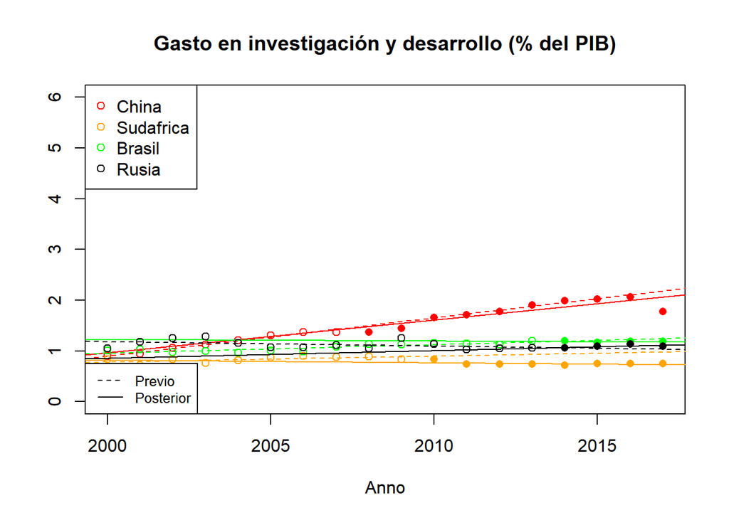

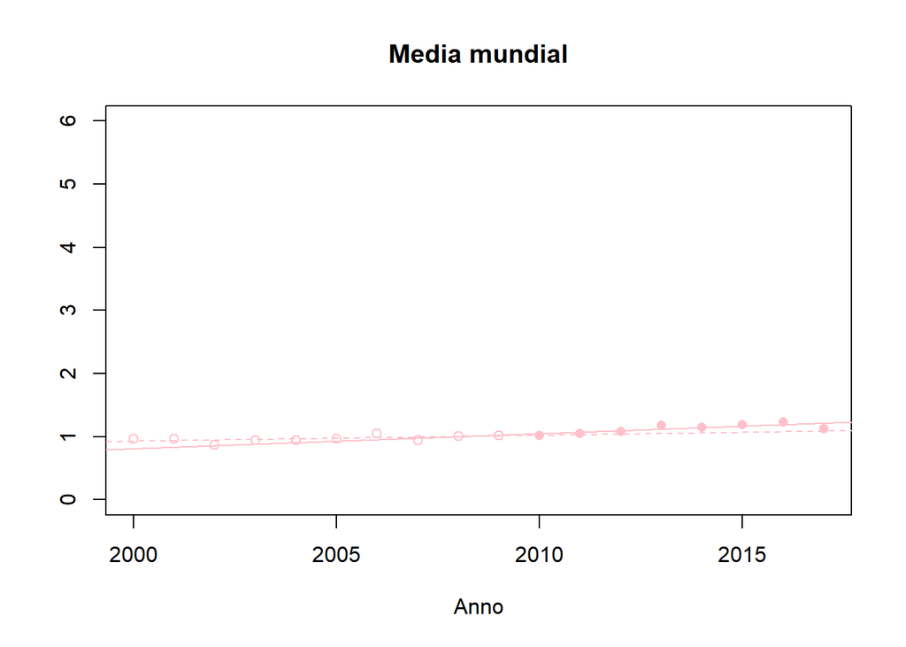

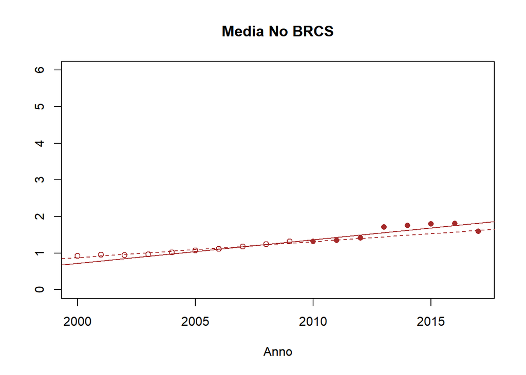

**Coeficientes de Correlacion - Gasto en investigación y desarrollo (% del PIB)**

| China |  |  |
| --- | --- | --- |
| Tendencia | 2000 - 2008 | POS |
| Correlación con Promedio mundial | 2000 - 2008 | 0.343 |
| Correlación con Promedio no BRCS | 2000 - 2008 | 0.918 |
| Tendencia | 2008 - 2017 | POS |
| Correlación con Promedio mundial | 2008 - 2017 | 0.706 |
| Correlación con Promedio no BRCS | 2008 - 2017 | 0.843 |
| Sudafrica |  |  |
| Tendencia | 2000 - 2010 | POS |
| Correlación con Promedio mundial | 2000 - 2010 | 0.351 |
| Correlación con Promedio no BRCS | 2000 - 2010 | 0.568 |
| Tendencia | 2010 - 2017 | NEG |
| Correlación con Promedio mundial | 2010 - 2017 | -0.343 |
| Correlación con Promedio no BRCS | 2010 - 2017 | -0.349 |
| Brasil |  |  |
| Tendencia | 2000 - 2014 | POS |
| Correlación con Promedio mundial | 2000 - 2014 | 0.745 |
| Correlación con Promedio no BRCS | 2000 - 2014 | 0.863 |
| Tendencia | 2014 - 2017 | NEG |
| Correlación con Promedio mundial | 2014 - 2017 | 0.377 |
| Correlación con Promedio no BRCS | 2014 - 2017 | -0.408 |
| Rusia |  |  |
| Tendencia | 2000 - 2014 | NEG |
| Correlación con Promedio mundial | 2000 - 2014 | -0.586 |
| Correlación con Promedio no BRCS | 2000 - 2014 | -0.458 |
| Tendencia | 2014 - 2017 | POS |
| Correlación con Promedio mundial | 2014 - 2017 | 0.221 |
| Correlación con Promedio no BRCS | 2014 - 2017 | 0.837 |

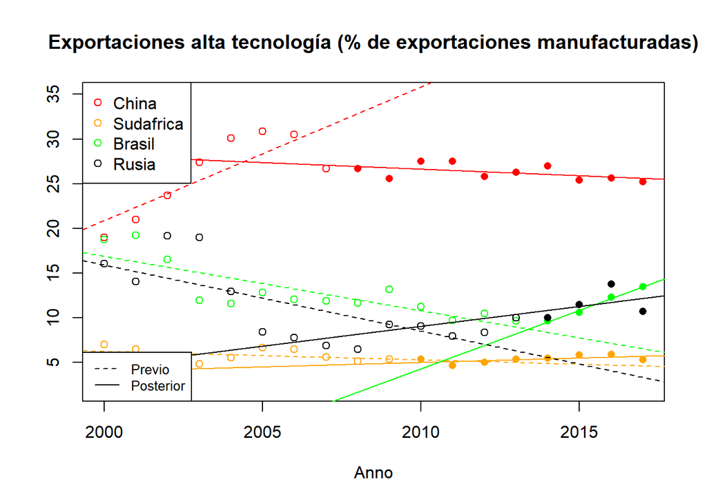

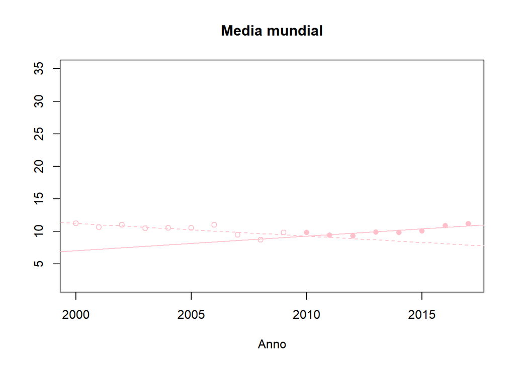

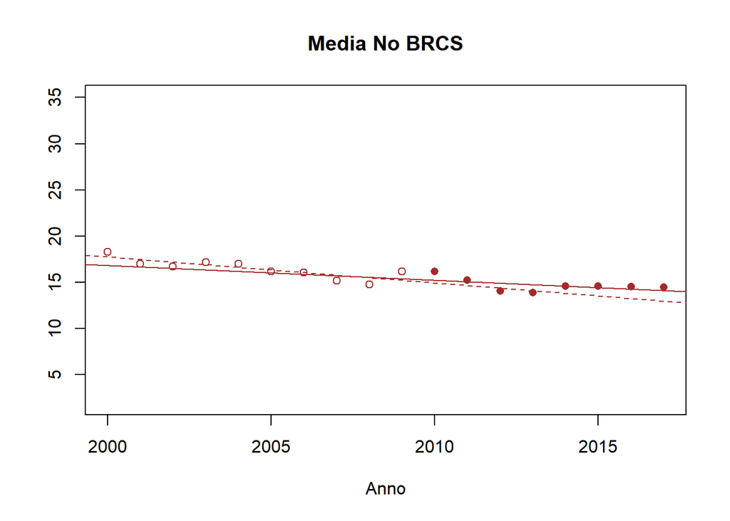

**Coeficientes de Correlacion - Exportaciones alta tecnología (% de exportaciones manufacturadas)**

| China |  |  |
| --- | --- | --- |
| Tendencia | 2000 - 2008 | POS |
| Correlación con Promedio mundial | 2000 - 2008 | -0.306 |
| Correlación con Promedio no BRCS | 2000 - 2008 | -0.601 |
| Tendencia | 2008 - 2017 | NEG |
| Correlación con Promedio mundial | 2008 - 2017 | -0.309 |
| Correlación con Promedio no BRCS | 2008 - 2017 | 0.284 |
| Sudafrica |  |  |
| Tendencia | 2000 - 2010 | NEG |
| Correlación con Promedio mundial | 2000 - 2010 | 0.524 |
| Correlación con Promedio no BRCS | 2000 - 2010 | 0.385 |
| Tendencia | 2010 - 2017 | POS |
| Correlación con Promedio mundial | 2010 - 2017 | 0.097 |
| Correlación con Promedio no BRCS | 2010 - 2017 | -0.711 |
| Brasil |  |  |
| Tendencia | 2000 - 2014 | NEG |
| Correlación con Promedio mundial | 2000 - 2014 | 0.635 |
| Correlación con Promedio no BRCS | 2000 - 2014 | 0.763 |
| Tendencia | 2014 - 2017 | POS |
| Correlación con Promedio mundial | 2014 - 2017 | 0.858 |
| Correlación con Promedio no BRCS | 2014 - 2017 | 0.665 |
| Rusia |  |  |
| Tendencia | 2000 - 2014 | NEG |
| Correlación con Promedio mundial | 2000 - 2014 | 0.666 |
| Correlación con Promedio no BRCS | 2000 - 2014 | 0.733 |
| Tendencia | 2014 - 2017 | POS |
| Correlación con Promedio mundial | 2014 - 2017 | -0.139 |
| Correlación con Promedio no BRCS | 2014 - 2017 | 0.654 |

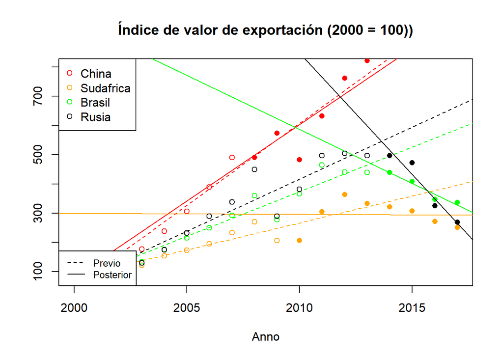

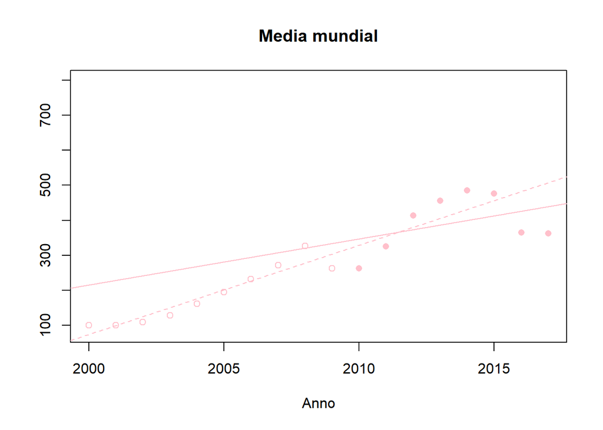

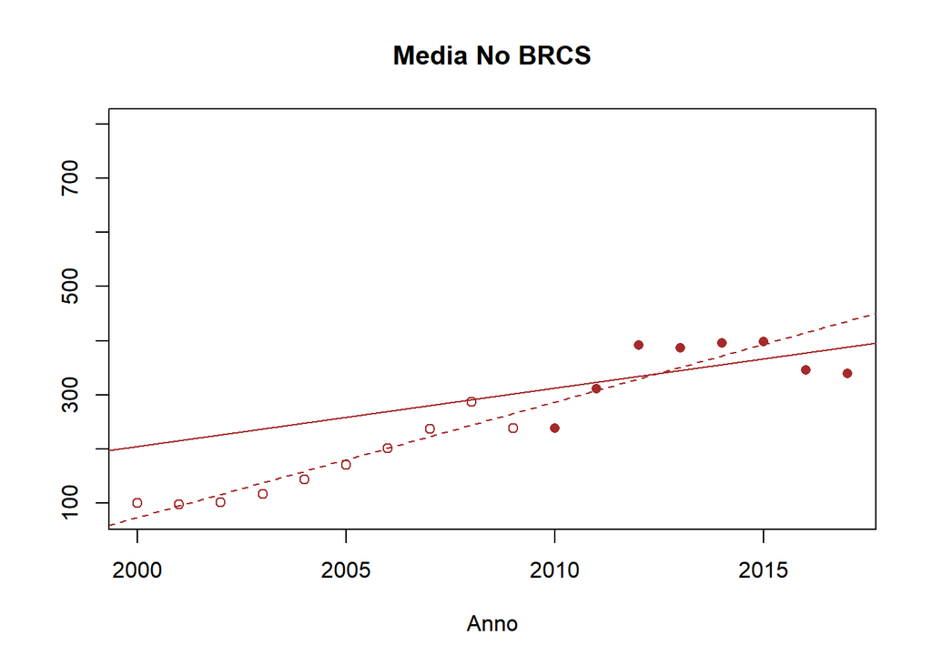

**Coeficientes de Correlacion - Índice de valor de exportación (2000 = 100))**

| China |  |  |
| --- | --- | --- |
| Tendencia | 2000 - 2008 | POS |
| Correlación con Promedio mundial | 2000 - 2008 | 0.999 |
| Correlación con Promedio no BRCS | 2000 - 2008 | 0.998 |
| Tendencia | 2008 - 2017 | POS |
| Correlación con Promedio mundial | 2008 - 2017 | 0.883 |
| Correlación con Promedio no BRCS | 2008 - 2017 | 0.905 |
| Sudafrica |  |  |
| Tendencia | 2000 - 2010 | POS |
| Correlación con Promedio mundial | 2000 - 2010 | 0.994 |
| Correlación con Promedio no BRCS | 2000 - 2010 | 0.989 |
| Tendencia | 2010 - 2017 | NEG |
| Correlación con Promedio mundial | 2010 - 2017 | 0.101 |
| Correlación con Promedio no BRCS | 2010 - 2017 | 0.192 |
| Brasil |  |  |
| Tendencia | 2000 - 2014 | POS |
| Correlación con Promedio mundial | 2000 - 2014 | 0.984 |
| Correlación con Promedio no BRCS | 2000 - 2014 | 0.994 |
| Tendencia | 2014 - 2017 | NEG |
| Correlación con Promedio mundial | 2014 - 2017 | 0.518 |
| Correlación con Promedio no BRCS | 2014 - 2017 | 0.476 |
| Rusia |  |  |
| Tendencia | 2000 - 2014 | POS |
| Correlación con Promedio mundial | 2000 - 2014 | 0.98 |
| Correlación con Promedio no BRCS | 2000 - 2014 | 0.982 |
| Tendencia | 2014 - 2017 | NEG |
| Correlación con Promedio mundial | 2014 - 2017 | 0.659 |
| Correlación con Promedio no BRCS | 2014 - 2017 | 0.613 |

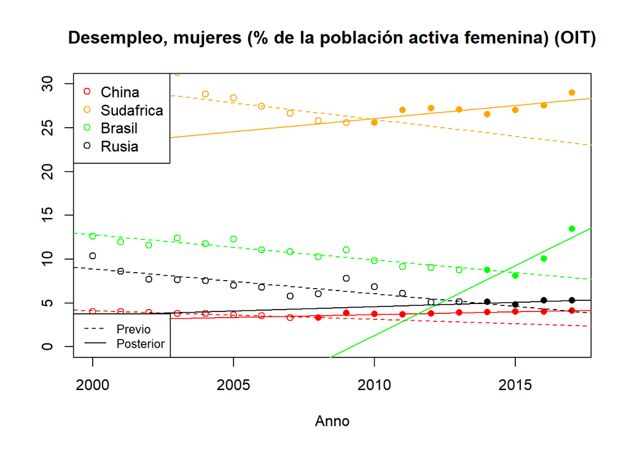

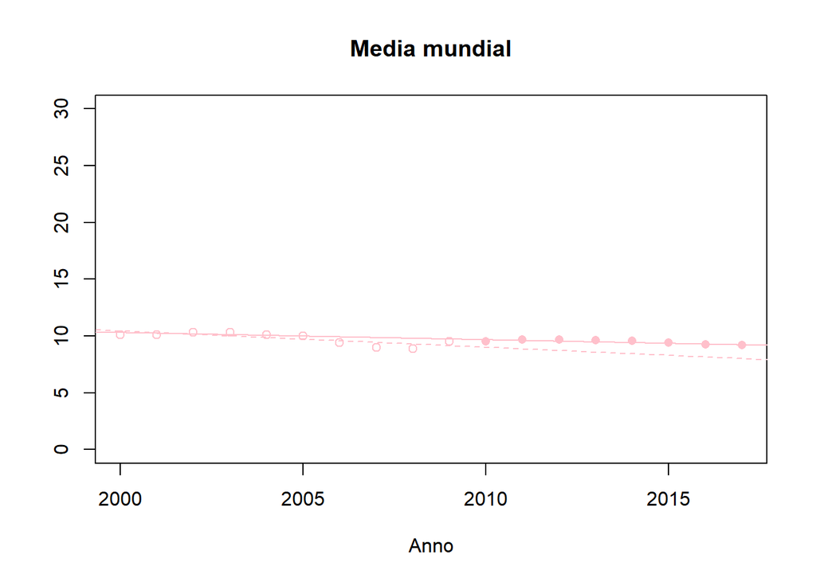

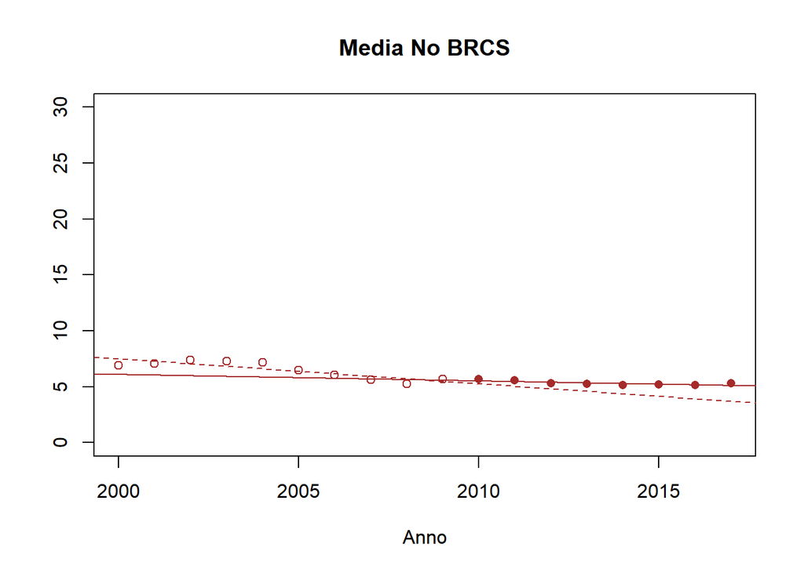

**Coeficientes de Correlacion - Desempleo, mujeres (% de la población activa femenina) (OIT)**

| China |  |  |
| --- | --- | --- |
| Tendencia | 2000 - 2008 | NEG |
| Correlación con Promedio mundial | 2000 - 2008 | 0.874 |
| Correlación con Promedio no BRCS | 2000 - 2008 | 0.858 |
| Tendencia | 2008 - 2017 | POS |
| Correlación con Promedio mundial | 2008 - 2017 | 0.026 |
| Correlación con Promedio no BRCS | 2008 - 2017 | -0.921 |
| Sudafrica |  |  |
| Tendencia | 2000 - 2010 | NEG |
| Correlación con Promedio mundial | 2000 - 2010 | 0.753 |
| Correlación con Promedio no BRCS | 2000 - 2010 | 0.823 |
| Tendencia | 2010 - 2017 | POS |
| Correlación con Promedio mundial | 2010 - 2017 | 0.215 |
| Correlación con Promedio no BRCS | 2010 - 2017 | -0.21 |
| Brasil |  |  |
| Tendencia | 2000 - 2014 | NEG |
| Correlación con Promedio mundial | 2000 - 2014 | 0.561 |
| Correlación con Promedio no BRCS | 2000 - 2014 | 0.864 |
| Tendencia | 2014 - 2017 | POS |
| Correlación con Promedio mundial | 2014 - 2017 | -0.939 |
| Correlación con Promedio no BRCS | 2014 - 2017 | -0.465 |
| Rusia |  |  |
| Tendencia | 2000 - 2014 | NEG |
| Correlación con Promedio mundial | 2000 - 2014 | 0.608 |
| Correlación con Promedio no BRCS | 2000 - 2014 | 0.737 |
| Tendencia | 2014 - 2017 | POS |
| Correlación con Promedio mundial | 2014 - 2017 | -0.724 |
| Correlación con Promedio no BRCS | 2014 - 2017 | 0.243 |

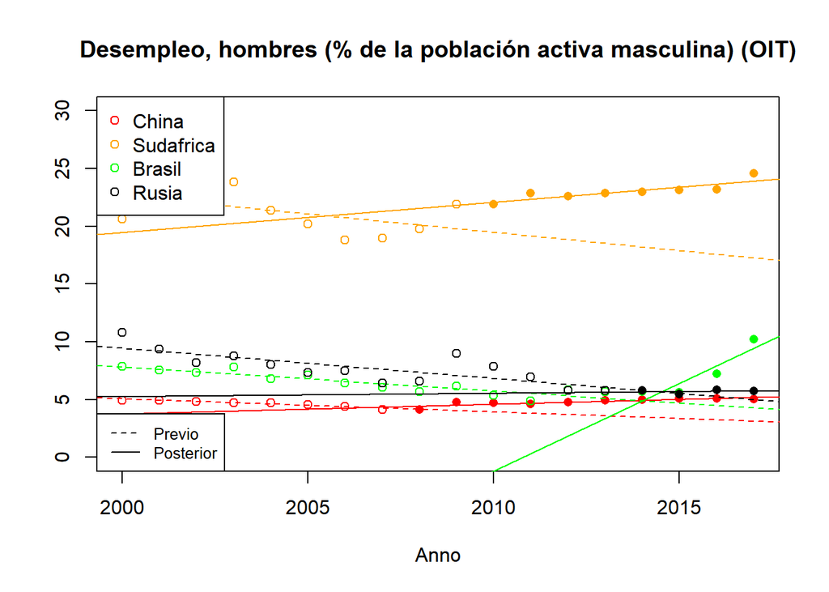

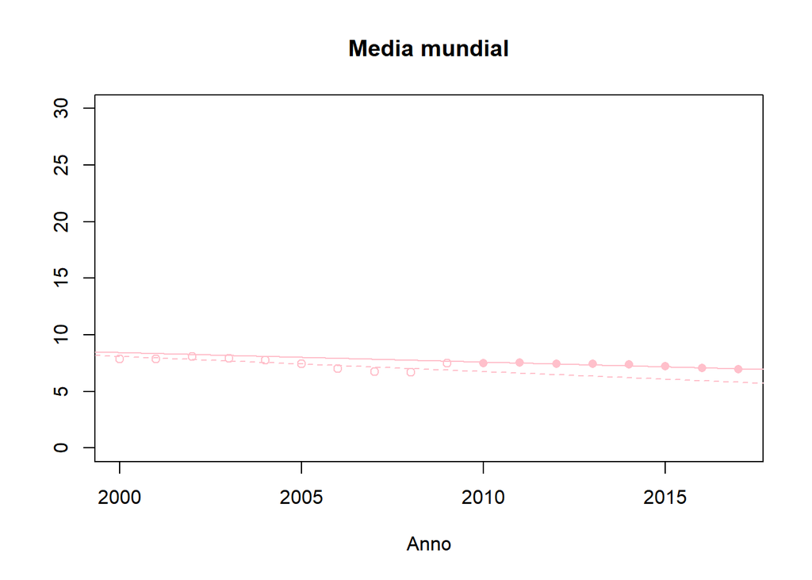

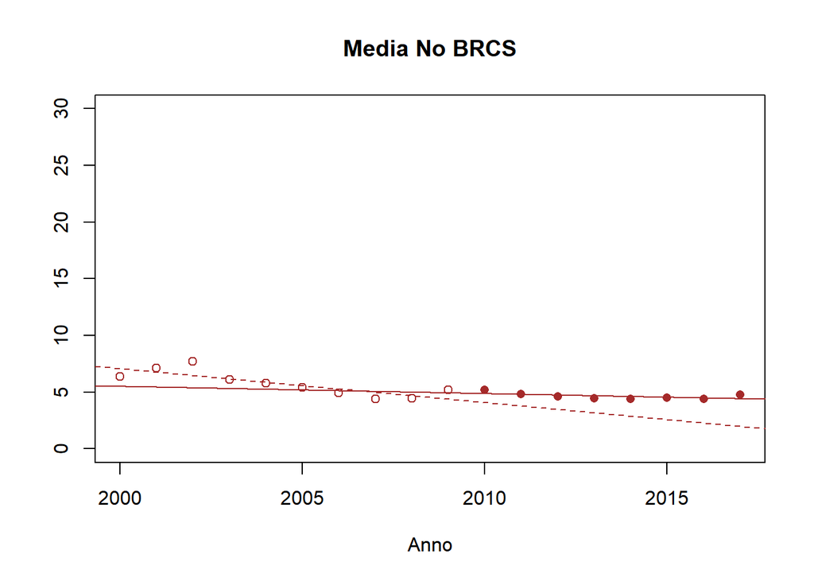

**Coeficientes de Correlacion - Desempleo, hombres (% de la población activa masculina) (OIT)**

| China |  |  |
| --- | --- | --- |
| Tendencia | 2000 - 2008 | NEG |
| Correlación con Promedio mundial | 2000 - 2008 | 0.932 |
| Correlación con Promedio no BRCS | 2000 - 2008 | 0.88 |
| Tendencia | 2008 - 2017 | POS |
| Correlación con Promedio mundial | 2008 - 2017 | 0.245 |
| Correlación con Promedio no BRCS | 2008 - 2017 | -0.647 |
| Sudafrica |  |  |
| Tendencia | 2000 - 2010 | NEG |
| Correlación con Promedio mundial | 2000 - 2010 | 0.834 |
| Correlación con Promedio no BRCS | 2000 - 2010 | 0.81 |
| Tendencia | 2010 - 2017 | POS |
| Correlación con Promedio mundial | 2010 - 2017 | 0.083 |
| Correlación con Promedio no BRCS | 2010 - 2017 | -0.261 |
| Brasil |  |  |
| Tendencia | 2000 - 2014 | NEG |
| Correlación con Promedio mundial | 2000 - 2014 | 0.617 |
| Correlación con Promedio no BRCS | 2000 - 2014 | 0.818 |
| Tendencia | 2014 - 2017 | POS |
| Correlación con Promedio mundial | 2014 - 2017 | -0.974 |
| Correlación con Promedio no BRCS | 2014 - 2017 | -0.199 |
| Rusia |  |  |
| Tendencia | 2000 - 2014 | NEG |
| Correlación con Promedio mundial | 2000 - 2014 | 0.632 |
| Correlación con Promedio no BRCS | 2000 - 2014 | 0.717 |
| Tendencia | 2014 - 2017 | POS |
| Correlación con Promedio mundial | 2014 - 2017 | -0.478 |
| Correlación con Promedio no BRCS | 2014 - 2017 | 0.715 |

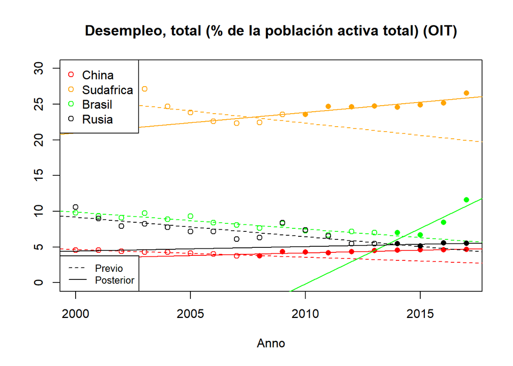

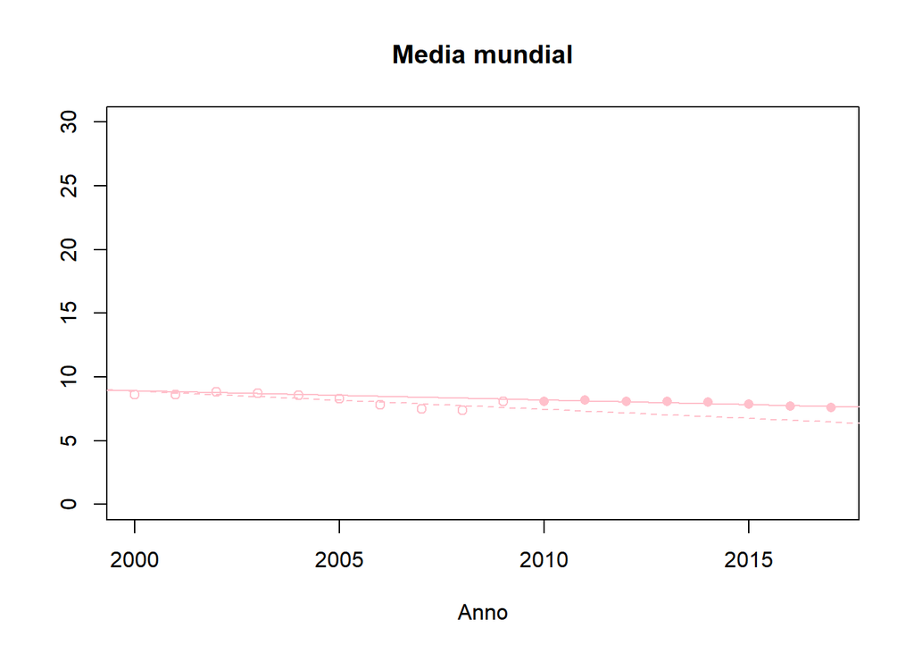

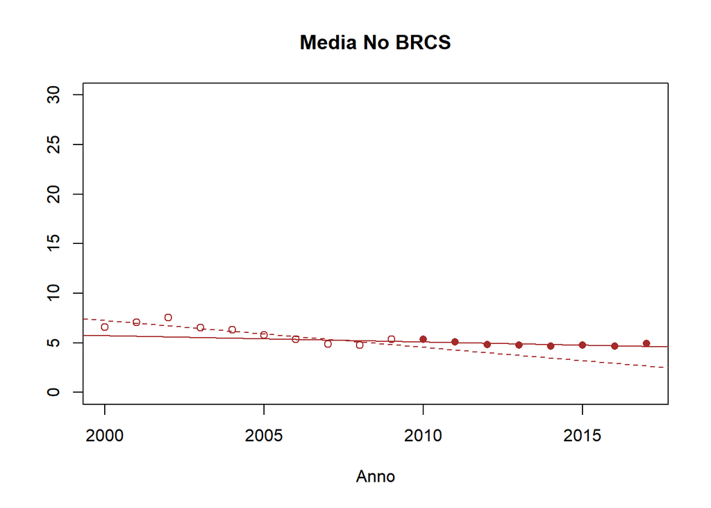

**Coeficientes de Correlacion - Desempleo, total (% de la población activa total) (OIT)**

| China |  |  |
| --- | --- | --- |
| Tendencia | 2000 - 2008 | NEG |
| Correlación con Promedio mundial | 2000 - 2008 | 0.922 |
| Correlación con Promedio no BRCS | 2000 - 2008 | 0.904 |
| Tendencia | 2008 - 2017 | POS |
| Correlación con Promedio mundial | 2008 - 2017 | 0.124 |
| Correlación con Promedio no BRCS | 2008 - 2017 | -0.841 |
| Sudafrica |  |  |
| Tendencia | 2000 - 2010 | NEG |
| Correlación con Promedio mundial | 2000 - 2010 | 0.824 |
| Correlación con Promedio no BRCS | 2000 - 2010 | 0.843 |
| Tendencia | 2010 - 2017 | POS |
| Correlación con Promedio mundial | 2010 - 2017 | 0.137 |
| Correlación con Promedio no BRCS | 2010 - 2017 | -0.241 |
| Brasil |  |  |
| Tendencia | 2000 - 2014 | NEG |
| Correlación con Promedio mundial | 2000 - 2014 | 0.635 |
| Correlación con Promedio no BRCS | 2000 - 2014 | 0.843 |
| Tendencia | 2014 - 2017 | POS |
| Correlación con Promedio mundial | 2014 - 2017 | -0.971 |
| Correlación con Promedio no BRCS | 2014 - 2017 | -0.353 |
| Rusia |  |  |
| Tendencia | 2000 - 2014 | NEG |
| Correlación con Promedio mundial | 2000 - 2014 | 0.657 |
| Correlación con Promedio no BRCS | 2000 - 2014 | 0.75 |
| Tendencia | 2014 - 2017 | POS |
| Correlación con Promedio mundial | 2014 - 2017 | -0.644 |
| Correlación con Promedio no BRCS | 2014 - 2017 | 0.519 |

[figure not shown]

[figure not shown]

[figure not shown]

**Coeficientes de Correlacion - Jóvenes sin educación, empleo ni capacitación (% total jóvenes)**

[output not shown]

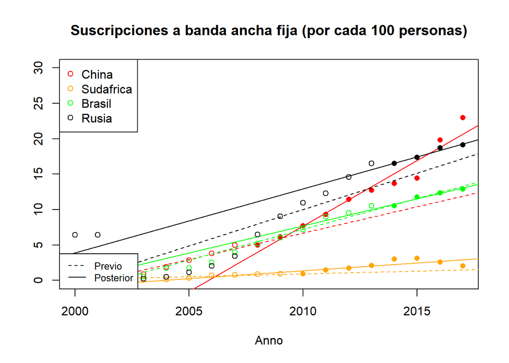

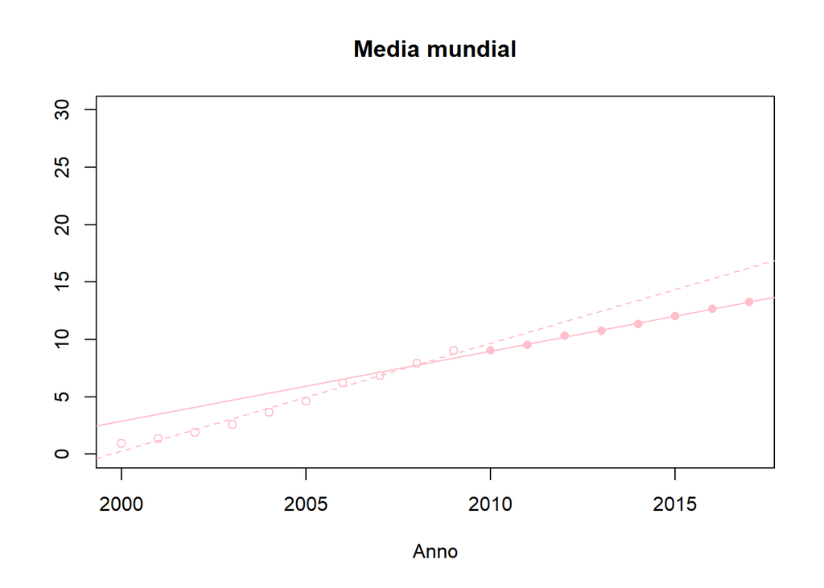

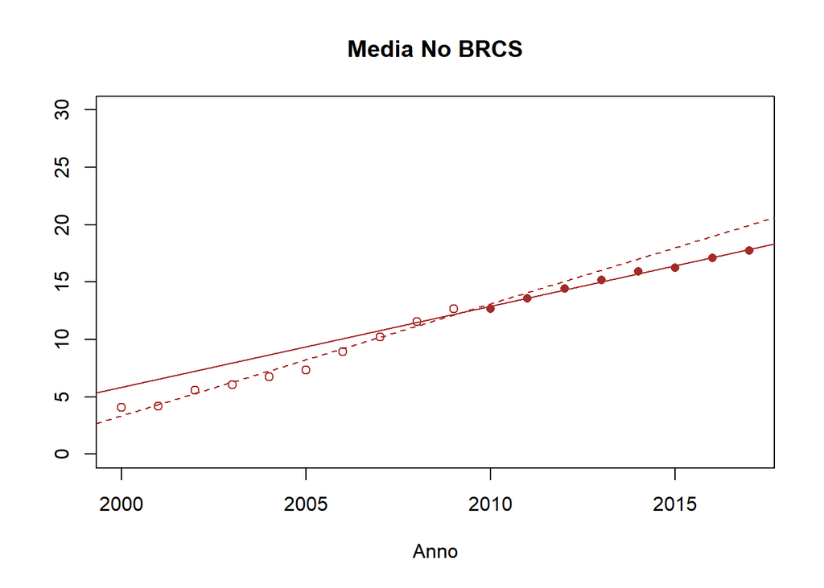

**Coeficientes de Correlacion - Suscripciones a banda ancha fija (por cada 100 personas)**

| China |  |  |
| --- | --- | --- |
| Tendencia | 2000 - 2008 | POS |
| Correlación con Promedio mundial | 2000 - 2008 | 0.992 |
| Correlación con Promedio no BRCS | 2000 - 2008 | 0.978 |
| Tendencia | 2008 - 2017 | POS |
| Correlación con Promedio mundial | 2008 - 2017 | 0.958 |
| Correlación con Promedio no BRCS | 2008 - 2017 | 0.937 |
| Sudafrica |  |  |
| Tendencia | 2000 - 2010 | POS |
| Correlación con Promedio mundial | 2000 - 2010 | 0.775 |
| Correlación con Promedio no BRCS | 2000 - 2010 | 0.752 |
| Tendencia | 2010 - 2017 | POS |
| Correlación con Promedio mundial | 2010 - 2017 | 0.714 |
| Correlación con Promedio no BRCS | 2010 - 2017 | 0.768 |
| Brasil |  |  |
| Tendencia | 2000 - 2014 | POS |
| Correlación con Promedio mundial | 2000 - 2014 | 0.97 |
| Correlación con Promedio no BRCS | 2000 - 2014 | 0.984 |
| Tendencia | 2014 - 2017 | POS |
| Correlación con Promedio mundial | 2014 - 2017 | 0.974 |
| Correlación con Promedio no BRCS | 2014 - 2017 | 0.966 |
| Rusia |  |  |
| Tendencia | 2000 - 2014 | POS |
| Correlación con Promedio mundial | 2000 - 2014 | 0.774 |
| Correlación con Promedio no BRCS | 2000 - 2014 | 0.803 |
| Tendencia | 2014 - 2017 | POS |
| Correlación con Promedio mundial | 2014 - 2017 | 0.986 |
| Correlación con Promedio no BRCS | 2014 - 2017 | 0.946 |

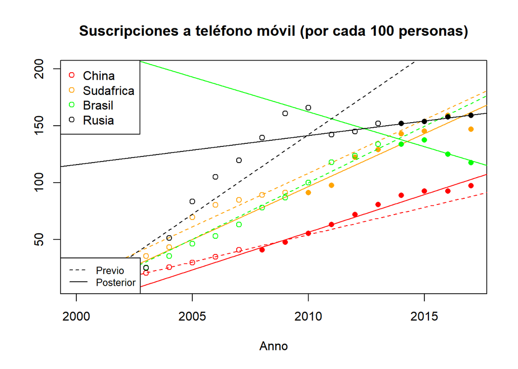

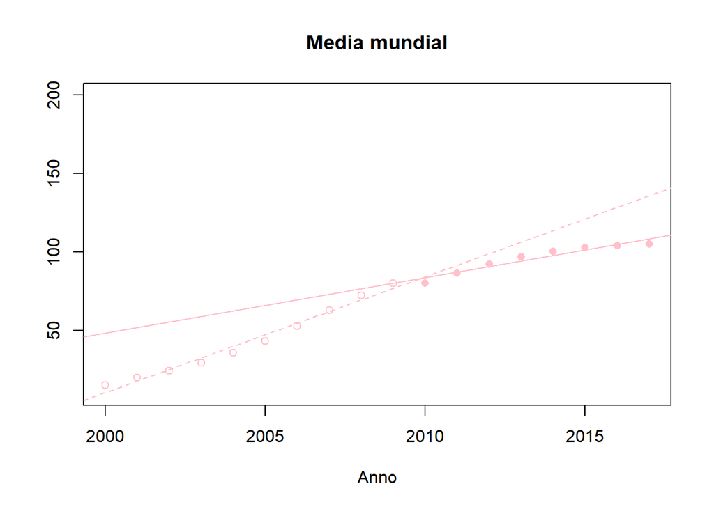

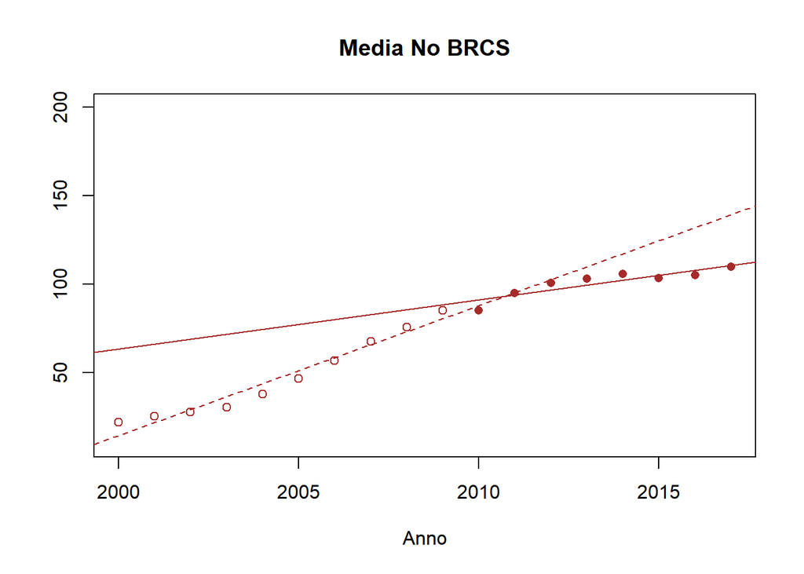

**Coeficientes de Correlacion - Suscripciones a teléfono móvil (por cada 100 personas)**

| China |  |  |
| --- | --- | --- |
| Tendencia | 2000 - 2008 | POS |
| Correlación con Promedio mundial | 2000 - 2008 | 0.991 |
| Correlación con Promedio no BRCS | 2000 - 2008 | 0.97 |
| Tendencia | 2008 - 2017 | POS |
| Correlación con Promedio mundial | 2008 - 2017 | 0.99 |
| Correlación con Promedio no BRCS | 2008 - 2017 | 0.975 |
| Sudafrica |  |  |
| Tendencia | 2000 - 2010 | POS |
| Correlación con Promedio mundial | 2000 - 2010 | 0.964 |
| Correlación con Promedio no BRCS | 2000 - 2010 | 0.96 |
| Tendencia | 2010 - 2017 | POS |
| Correlación con Promedio mundial | 2010 - 2017 | 0.975 |
| Correlación con Promedio no BRCS | 2010 - 2017 | 0.947 |
| Brasil |  |  |
| Tendencia | 2000 - 2014 | POS |
| Correlación con Promedio mundial | 2000 - 2014 | 0.99 |
| Correlación con Promedio no BRCS | 2000 - 2014 | 0.991 |
| Tendencia | 2014 - 2017 | NEG |
| Correlación con Promedio mundial | 2014 - 2017 | -0.798 |
| Correlación con Promedio no BRCS | 2014 - 2017 | 0.01 |
| Rusia |  |  |
| Tendencia | 2000 - 2014 | POS |
| Correlación con Promedio mundial | 2000 - 2014 | 0.954 |
| Correlación con Promedio no BRCS | 2000 - 2014 | 0.95 |
| Tendencia | 2014 - 2017 | POS |
| Correlación con Promedio mundial | 2014 - 2017 | 0.965 |
| Correlación con Promedio no BRCS | 2014 - 2017 | 0.192 |

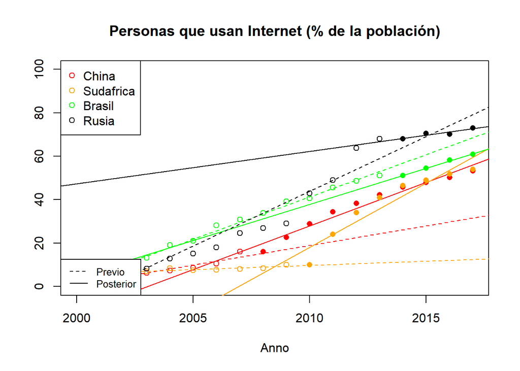

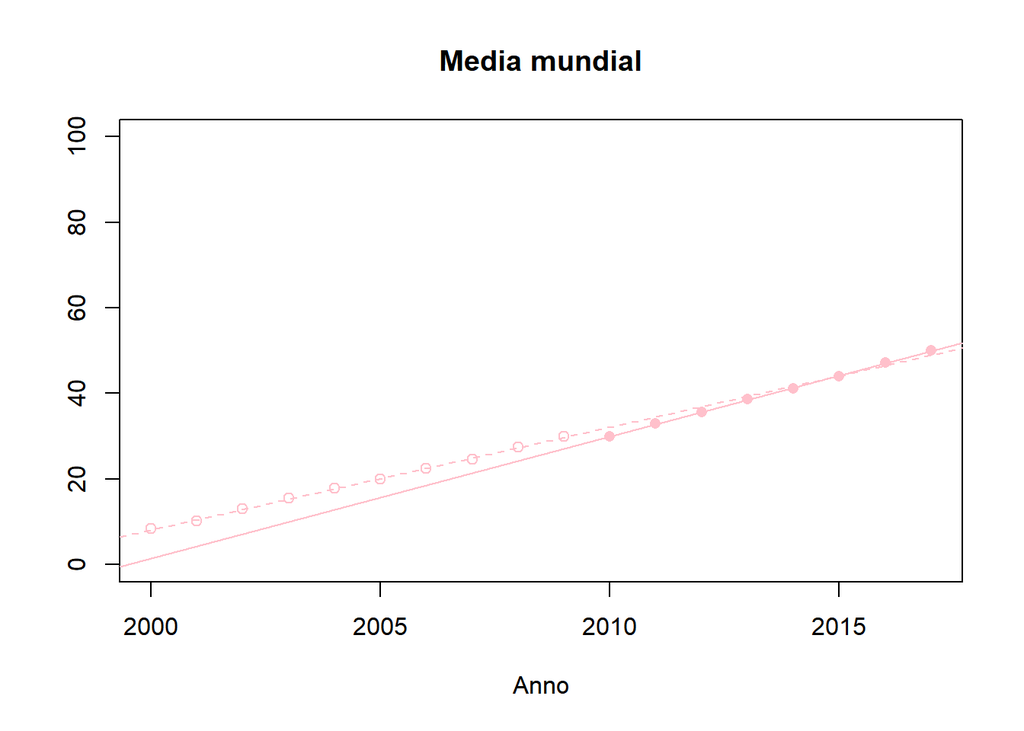

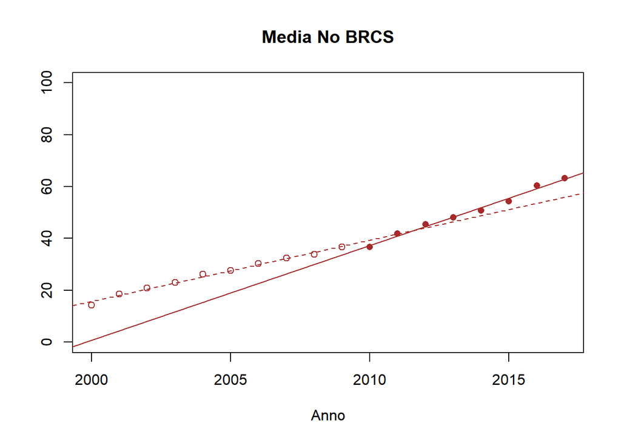

**Coeficientes de Correlacion - Personas que usan Internet (% de la población)**

| China |  |  |
| --- | --- | --- |
| Tendencia | 2000 - 2008 | POS |
| Correlación con Promedio mundial | 2000 - 2008 | 0.96 |
| Correlación con Promedio no BRCS | 2000 - 2008 | 0.944 |
| Tendencia | 2008 - 2017 | POS |
| Correlación con Promedio mundial | 2008 - 2017 | 0.978 |
| Correlación con Promedio no BRCS | 2008 - 2017 | 0.96 |
| Sudafrica |  |  |
| Tendencia | 2000 - 2010 | POS |
| Correlación con Promedio mundial | 2000 - 2010 | 0.912 |
| Correlación con Promedio no BRCS | 2000 - 2010 | 0.925 |
| Tendencia | 2010 - 2017 | POS |
| Correlación con Promedio mundial | 2010 - 2017 | 0.946 |
| Correlación con Promedio no BRCS | 2010 - 2017 | 0.944 |
| Brasil |  |  |
| Tendencia | 2000 - 2014 | POS |
| Correlación con Promedio mundial | 2000 - 2014 | 0.994 |
| Correlación con Promedio no BRCS | 2000 - 2014 | 0.986 |
| Tendencia | 2014 - 2017 | POS |
| Correlación con Promedio mundial | 2014 - 2017 | 0.993 |
| Correlación con Promedio no BRCS | 2014 - 2017 | 0.968 |
| Rusia |  |  |
| Tendencia | 2000 - 2014 | POS |
| Correlación con Promedio mundial | 2000 - 2014 | 0.971 |
| Correlación con Promedio no BRCS | 2000 - 2014 | 0.977 |
| Tendencia | 2014 - 2017 | POS |
| Correlación con Promedio mundial | 2014 - 2017 | 0.921 |
| Correlación con Promedio no BRCS | 2014 - 2017 | 0.928 |